# Testes de Hipóteses

Cristofer Weber

09/06/2018

## Testes A/B, Experimentos (1)

Objetivo:

- Confirmar ou rejeitar uma hipótese que envolva causalidade:
  - Medicamento A cura mais pacientes que a medicação padrão
  - Preço A resulta em maior lucratividade que o preço B
- Não podemos estabelecer a relação causa-efeito sem designar um experimento apropriado
  - Como determinar que o medicamento A curou mais pacientes sem controlar para que outros fatores não influenciem no resultado?
  - Grupo de Controle, Grupo de Tratamento, Randomização

## Testes A/B, Experimentos (2)

[figure not shown]

## Testes A/B, Experimentos (3)

*Pipeline*:

1. Formulação da hipótese
2. Experimento para testar a hipótese (qual tipo de teste)
   - Estimador: (Média, Desvio Padrão, Distribuição) para testar a hipótese nula
3. Coleta de dados (conjunto limitado) e análise
   - Valor da estatística (Teste Z, teste t) - baseados em tabelas
   - Significância
4. Conclusão

Inferência:

- Aplicação dos resultados dos experimentos, baseados em um conjunto limitado de dados, em uma população ou em um processo.

## Testes A/B, Experimentos (4)

[figure not shown]

## Testes de hipóteses: Conceitos

- Hipótese Nula (Ho)
  - A hipótese que buscamos refutar
- Hipótese Alternativa (Ha)
  - A hipótese que esperamos validar
- Nível de Significância
  - Probabilidade de rejeitar a hipótese nula quando ela é verdadeira (Erro tipo I), usualmente 5% ou 1%.
- Diferenças
  - Hipótese Nula: “Não há diferença entre grupos”, Alternativa: “A é diferente de B” (pode ser maior ou menor)
  - Hipótese Nula: “Não há diferença entre grupos”, Alternativa: “A é maior que B”
  - Hipótese Nula: “Não há diferença entre grupos”, Alternativa: “A é menor que B”

## Erros tipo I e II


## Atualmente, em muitos casos

- Dados já estão coletados (observacionais)
- Dados coletados não atendem totalmente os requisitos para experimento
- Hipóteses não podem estabelecer causalidade, pois não há controle sobre os dados já coletados
  - Isso não invalida o uso dos dados para testar hipóteses

## Exemplo: TED Talks

Os vídeos são avaliados em diferentes critérios estabelecidos pela comunidade:

- Critérios positivos, como:
  - Divertido, Inspirador, Belo, De cair o queixo (jaw-dropping)
- Critérios negativos:
  - Muito verboso (Longwinded), Desagradável (Obnoxious), Pouco Convincente

## Exemplo: TED Talks

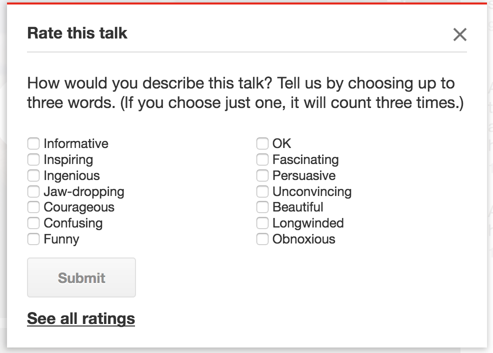

## TED talks: Grupos e médias

Agrupando os vídeos de acordo com a categoria mais votada de cada vídeo e observando a média de visualizações por vídeos, temos os seguintes destaques:

- De cair o queixo (*Jaw-dropping*): Média de mais de 3.5 milhões de visualizações
- Divertidos: Média de 2.17 milhões de visualizações
- Inspiradores: Média de 1.97 milhões de visualizações

**Reparem que o *rank* da mediana difere do rank da média**

```r
library(MonetDBLite)
library(tidyverse)

if( str_detect(getwd(), "notebooks")) {
  dbdir <- "../data/monetdb/ted"
} else {
  dbdir <- "aula-08/data/monetdb/ted"
}

ted_conn <- MonetDBLite::src_monetdblite(dbdir)
ted_main <- tbl( ted_conn, "ted_main" )

ted_main %>%
  group_by(category) %>%
  summarise( mean   = mean( views )
           , sd     = sd( views )
           , median = median( views )
           , iqr    = quantile( views, 0.75 ) - quantile( views, 0.25 )
           , length = n_distinct( url )) %>%
  ungroup() %>%
  arrange(desc(mean)) -> query_summary_ted_main

query_summary_ted_main
```

| category | mean | sd | median | iqr | length |
| --- | --- | --- | --- | --- | --- |
| Jaw-dropping | 3519450.5 | 3643733.2 | 1965808 | 2978117 | 54 |
| Funny | 2171608.3 | 2774888.0 | 1486880 | 1389877 | 163 |
| Inspiring | 1968876.7 | 3334706.4 | 1163387 | 1070020 | 881 |
| Courageous | 1876227.8 | 2616951.6 | 1175629 | 1043856 | 85 |
| Fascinating | 1775792.5 | 1980707.3 | 1231159 | 1191293 | 266 |
| Informative | 1412572.7 | 1593572.6 | 1108371 | 710189 | 726 |
| Persuasive | 1142157.6 | 838722.5 | 898974 | 848615 | 83 |
| Beautiful | 1118023.6 | 827907.4 | 891589 | 718482 | 153 |
| Ingenious | 997782.5 | 689284.8 | 862689 | 579214 | 103 |
| Unconvincing | 930000.0 | 449938.6 | 922158 | 549153 | 24 |

[output cut: 4 more lines]

## Visualizações em boxplots

Inclusão de *notch* (entalhe) para comparação das medianas. Os entalhes aproximam um intervalo de confiança de 95% da mediana. Quanto menor o tamanho da amostra, maior será o tamanho do *notch*. “De cair o queixo” é a categoria de menor número de observações entre as 3, e *Inspiring* possui o maior N.

[Referência sobre *notches* em Boxplots.](https://www.nature.com/articles/nmeth.2813)

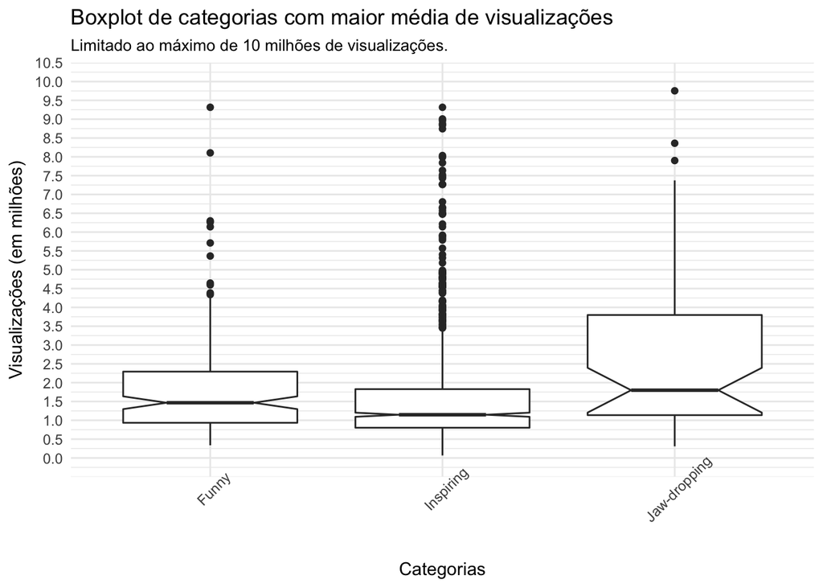

```r
ted_top_categories <-
  ted_main %>%
  filter(category %in% c("Jaw-dropping", "Funny", "Inspiring"))

ted_top_categories %>%
  collect() %>%
  ggplot(aes(x=category, y=views / 1000000)) +
  geom_boxplot(notch = TRUE) +
  scale_y_continuous(limits=c(0, 10), breaks = seq(from=0, to=50, by = 0.5)) +
  theme_minimal() +
  theme(axis.text.x = element_text(angle=45)) +
  labs( x = "Categorias"
      , y = "Visualizações (em milhões)"
      , title = "Boxplot de categorias com maior média de visualizações"
      , subtitle = "Limitado ao máximo de 10 milhões de visualizações.")
```

## Teste U de Mann-Whitney

O [teste de U de Mann-Whitney](https://en.wikipedia.org/wiki/Mann%E2%80%93Whitney_U_test), também conhecido como teste de Wilcoxon-Mann-Whitney, é um teste não paramétrico equivalente ao mais conhecido teste t, e é aplicado nos casos em que não se pode assumir

- que a distribuição da população segue uma distribuição gaussiana.
- que os tamanhos das amostras são os mesmos.

Neste teste estamos determinando se duas amostras (público que visualiza diferentes categorias de vídeos) são heterogêneas.

- Sob a hipótese nula, a distribuição de ambos os grupos é a mesma.
- Sob a hipótese alternativa, há diferença nas medianas.
  - P(X > Y) <> P(Y > X)

A estatística calulada é uma estimativa da mediana da diferença entre amostras de x e de y.

Testes não paramétricos são mais aplicáveis que seus equivalentes paramétricos por assumirem menos restrições. Por utilizarem *ranks* (quantis) são também mais robustos a *outliers*. [Comparação com o teste t de Student](https://en.wikipedia.org/wiki/Mann%E2%80%93Whitney_U_test#Comparison_to_Student's_t-test).

O resultado **U** (estatística U) apresentado pelo teste (ou **W** no caso da implementação em R) é um valor que historicamente era consultado em tabela de significância, tal como os testes t e Z, e corresponde à soma dos *ranks* definidos para os dois conjuntos. [Detalhes na Wikipedia](https://en.wikipedia.org/wiki/Mann%E2%80%93Whitney_U_test#Calculations).

## Teste U de Mann-Whitney - Grupos Funny e Inspiring

```r
wilcox.test(views ~ category, data = ted_top_categories, alternative = "two.sided", subset = category %in% c("Inspiring", "Funny"), conf.int = TRUE)
```

```
##
##  Wilcoxon rank sum test with continuity correction
##
## data:  views by category
## W = 82541, p-value = 0.002391
## alternative hypothesis: true location shift is not equal to 0
## 95 percent confidence interval:
##   77287 363057
## sample estimates:
## difference in location
##                 216306
```

## Teste U de Mann-Whitney - Grupos Jaw-dropping e Inspiring

```r
wilcox.test(views ~ category, data = ted_top_categories, alternative = "two.sided", subset = category %in% c("Inspiring", "Jaw-dropping"), conf.int = TRUE)
```

```
##
##  Wilcoxon rank sum test with continuity correction
##
## data:  views by category
## W = 14316, p-value = 8.818e-07
## alternative hypothesis: true location shift is not equal to 0
## 95 percent confidence interval:
##  -1238670  -486984
## sample estimates:
## difference in location
##              -814614.5
```

## Teste U de Mann-Whitney - Grupos Jaw-dropping e Funny

```r
wilcox.test(views ~ category, data = ted_top_categories, alternative = "two.sided", subset = category %in% c("Funny", "Jaw-dropping"), conf.int = TRUE)
```

```
##
##  Wilcoxon rank sum test with continuity correction
##
## data:  views by category
## W = 3177, p-value = 0.002216
## alternative hypothesis: true location shift is not equal to 0
## 95 percent confidence interval:
##  -1078515  -225303
## sample estimates:
## difference in location
##              -614328.2
```

## Teste de grupos com Kruskal-Wallis

O teste de Kruskal-Wallis testa as hipóteses:

- Ho: os parâmetros de localização da distribuição de visualizações é o mesmo em cada grupo
- Ha: Ao menos um dos grupos difere dos demais

```r
ted_top_categories %>%
  collect() %>%
  mutate( category = factor( category )) -> local_ted_top_categories

kruskal.test(views ~ category, data = local_ted_top_categories)
```

```
##
##  Kruskal-Wallis rank sum test
##
## data:  views by category
## Kruskal-Wallis chi-squared = 31.199, df = 2, p-value = 1.68e-07
```

## Teste entre pares de grupos com Mann-Whitney

Uma vez detectada a diferença entre ao menos um grupo e os demais, passa a ser necessário testar as combinações de pares. De forma similar o que fizemos anteriormente, mas com uma única função. Percebam que esta função retorna somente os *p-values*.

Método de ajuste do *p-value*:

```r
pairwise.wilcox.test(local_ted_top_categories$views, local_ted_top_categories$category, p.adjust.method = "BH")
```

```
##
##  Pairwise comparisons using Wilcoxon rank sum test
##
## data:  local_ted_top_categories$views and local_ted_top_categories$category
##
##              Funny  Inspiring
## Inspiring    0.0024 -
## Jaw-dropping 0.0024 2.6e-06
##
## P value adjustment method: BH
```

## Múltiplos testes e a necessidade de ajustar os *p-values*.

## Múltiplos testes e a necessidade de ajustar os *p-values*.

> Torture os números que eles confessam.
- Continue testando continuamente e invariavelmente aparecerá um efeito estatisticamente significante.

Este é um erro similar ao erro de *overfitting* em *Machine Learning*, necessitando de um procedimento para corrigir este erro.

O mecanismo mais comum de ajuste é o ajuste de Bonferroni, que é um ajuste bastante conservador. Outros mecanismos implementados na linguagem R estão disponíveis no help da função `p.adjust` (`help(p.adjust)` ou `?p.adjust`), sendo Benjamini & Yekutieli (BY) e Benjamini & Hochberg (BH) os métodos mais recentes.

## Testando todas as categorias (boxplot)

Confusing, Longwinded, Ok e Obnoxious ficaram com o *notch* mais longo que o 1o e o 3o quartil.

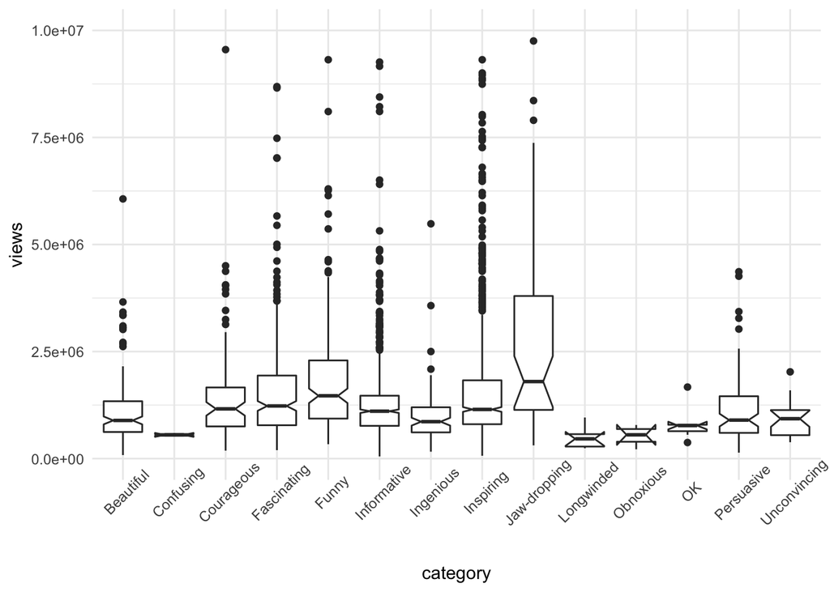

```r
ted_main %>%
  collect() %>%
  ggplot( aes( x = category, y = views )) +
  geom_boxplot( notch = TRUE ) +
  scale_y_continuous( limits = c( 0, 1*10^7 )) +
  theme_minimal() +
  theme( axis.text.x = element_text( angle = 45 ))
```

## Testando todas as categorias (Mann-Whitney)

```r
with( collect( ted_main ) %>% mutate( category = factor( category )),
     pairwise.wilcox.test(views, category, p.adjust.method = "BH")) ->
  pairwise_matrix

pairwise_matrix
```

```
##
##  Pairwise comparisons using Wilcoxon rank sum test
##
## data:  views and category
##
##              Beautiful Confusing Courageous Fascinating Funny
## Confusing    0.19957   -         -          -           -
## Courageous   0.00782   0.12490   -          -           -
## Fascinating  1.3e-05   0.08738   0.61941    -           -
## Funny        1.0e-08   0.05814   0.05171    0.03959     -
## Informative  0.00147   0.10137   0.31878    0.00574     1.5e-06
## Ingenious    0.51524   0.20294   0.00201    2.8e-06     2.3e-09
## Inspiring    2.9e-06   0.09117   0.76991    0.64573     0.00622
## Jaw-dropping 1.7e-09   0.04546   0.00016    2.8e-05     0.00593
## Longwinded   0.00485   0.75245   0.00165    0.00045     0.00016
## Obnoxious    0.08738   1.00000   0.02957    0.01977     0.01055
## OK           0.36513   0.39912   0.08738    0.04841     0.01548
## Persuasive   0.83360   0.21592   0.04084    0.00153     8.4e-06
## Unconvincing 0.61039   0.40727   0.04546    0.00733     0.00036
##              Informative Ingenious Inspiring Jaw-dropping Longwinded
## Confusing    -           -         -         -            -
## Courageous   -           -         -         -            -
## Fascinating  -           -         -         -            -
## Funny        -           -         -         -            -
## Informative  -           -         -         -            -
## Ingenious    0.00019     -         -         -            -
## Inspiring    0.00211     1.2e-06   -         -            -
## Jaw-dropping 7.2e-09     5.2e-10   7.3e-06   -            -
## Longwinded   0.00070     0.00593   0.00058   0.00012      -
## Obnoxious    0.02408     0.08738   0.01969   0.00634      0.83360
## OK           0.07853     0.44362   0.04546   0.00354      0.08341
## Persuasive   0.04771     0.44362   0.00158   7.8e-08      0.00811
## Unconvincing 0.04829     0.97386   0.01102   1.1e-05      0.01607
##              Obnoxious OK      Persuasive
## Confusing    -         -       -
## Courageous   -         -       -
## Fascinating  -         -       -
## Funny        -         -       -
## Informative  -         -       -
## Ingenious    -         -       -
## Inspiring    -         -       -
## Jaw-dropping -         -       -
## Longwinded   -         -       -
## Obnoxious    -         -       -
## OK           0.29108   -       -
## Persuasive   0.08738   0.36513 -
## Unconvincing 0.14680   0.61728 0.57143
##
## P value adjustment method: BH
```

## Intuição para um teste de hipóteses

- A hipótese nula afirma que não há diferença entre grupos.
- Desta forma, se combinarmos valores dos grupos A e B, não devemos perceber diferenças.
  - Não há diferença entre os grupos, então por que considerar que os valores são observações de um grupo específico?

```r
perm_fun <- function( v_1, v_2 ) {
  x <- c( v_1, v_2 )
  n1 <- length( v_1 )
  n2 <- length( v_2 )
  n <- n1 + n2
  idx_b <- sample(1:n, n1)
  idx_a <- setdiff(1:n, idx_b)
  mean_diff <- mean(x[idx_b]) - mean(x[idx_a])
  return(mean_diff)
}

pull_views_from <- function( tbl, which_category ) {
  tbl %>% filter( category == which_category ) %>% pull( views )
}

plot_diffs <- function( permutation_diffs, mean_1, mean_2 ) {
    ggplot( aes( x = permutation_diffs ), data = data_frame( permutation_diffs )) +
    geom_histogram( bins = 100, fill = "lightgray", color = "black", alpha = 0.6 ) +
    geom_vline( xintercept = mean_1 - mean_2 ) +
    theme_minimal()
}
```

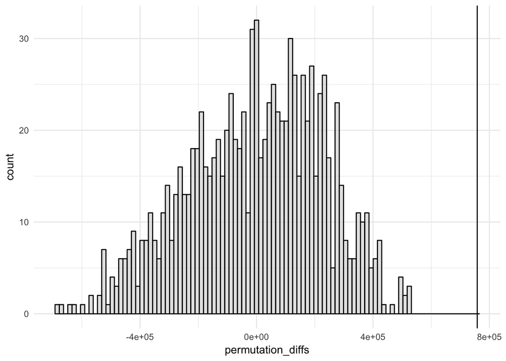

```r
perm_diffs <- rep(0, 1000)

all_courageous  <- pull_views_from( ted_main, which_category = "Courageous" )
all_beautiful   <- pull_views_from( ted_main, which_category = "Beautiful"  )
mean_courageous <- mean( all_courageous )
mean_beautiful  <- mean( all_beautiful )

for(i in 1:1000)
  perm_diffs[i] = perm_fun( all_beautiful, all_courageous )

plot_diffs( perm_diffs, mean_courageous, mean_beautiful )
```

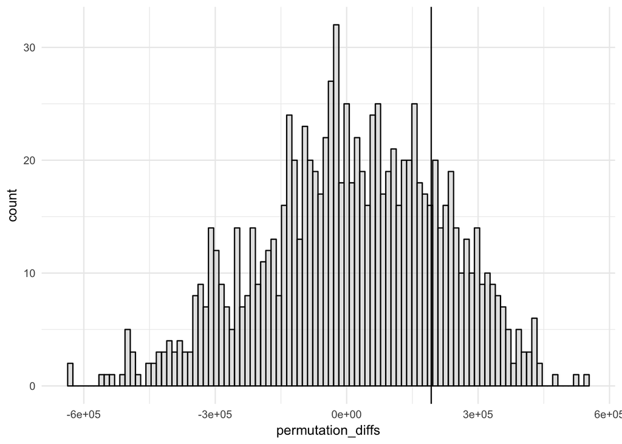

```r
perm_diffs <- rep(0, 1000)

all_inspiring    <- pull_views_from( ted_main, which_category = "Inspiring" )
all_fascinating  <- pull_views_from( ted_main, which_category = "Fascinating"  )
mean_inspiring   <- mean( all_inspiring )
mean_fascinating <- mean( all_fascinating )

for(i in 1:1000)
  perm_diffs[i] = perm_fun( all_inspiring, all_fascinating )

plot_diffs( perm_diffs, mean_inspiring, mean_fascinating )
```

### Neste caso, como testar?

```r
# Falamos sobre Funções de distribuição cumulativa na aula sobre testes.
# A função ecdf cria uma distribuição cumulativa empírica a partir de uma série de valores observados
f <- ecdf(perm_diffs)

# Qual a probabilidade de observarmos uma diferença do tamanho da diferença entre as médias de visualização dos vídeos categorizados como Inspiring e dos vídeos categorizados como Fascinating?
1 - f(mean_inspiring - mean_fascinating)
```

```
## [1] 0.203
```

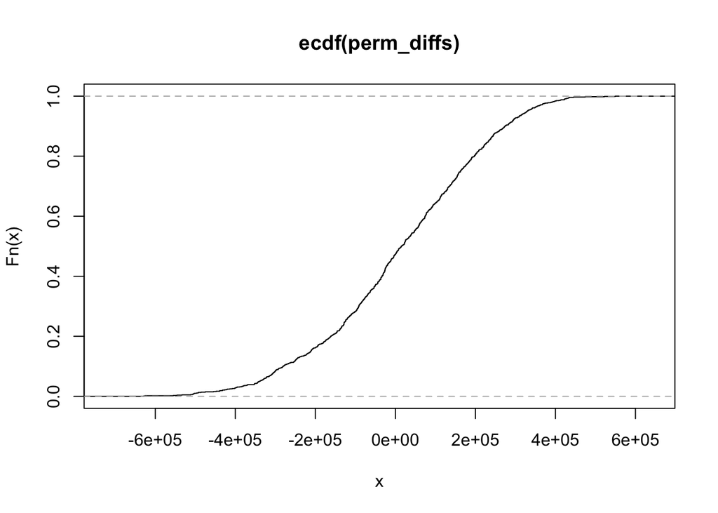

```r
plot(f)
```

```r
summary(f)
```

```
## Empirical CDF:     1000 unique values with summary
##    Min. 1st Qu.  Median    Mean 3rd Qu.    Max.
## -628902 -124614   15112   11046  162384  549640
```

# Finalização, desconecta do banco de dados

```r
MonetDBLite::monetdblite_shutdown()
```

## ATIVIDADE

1. Selecione um par de categorias **não apresentado anteriormente** nos gráficos
   - Apresentados: Inspiring x Fascinating, Courageous x Beautiful
   - Dê preferência para categorias com mais de 50 observações
2. Aplicar o Teste U de Mann-Whitney
3. Aplicar o teste de permutações com 5000 repetições e exibir o gráfico com histograma e linha vertical da diferença entre as médias.
4. Determinar em qual quantil (percentual inteiro, por exemplo, 81%) se encontra a diferença entre as médias (traçada como linha vertical)